# FINAL ASSIGNMENT

## Student : Leonardo Patricelli

## ID : 101292853

## BUS 4023 - WINTER 2021

Loading the dataset

```python
import pandas as pd

df = pd.read_csv("BathSoapHousehold.csv")
print('dimension:',df.shape)
df
```

```
dimension: (600, 46)
```

|  | Member id | SEC | FEH | MT | SEX | AGE | EDU | HS | CHILD | CS | ... | PropCat 6 | PropCat 7 | PropCat 8 | PropCat 9 | PropCat 10 | PropCat 11 | PropCat 12 | PropCat 13 | PropCat 14 | PropCat 15 |
| --- | --- | --- | --- | --- | --- | --- | --- | --- | --- | --- | --- | --- | --- | --- | --- | --- | --- | --- | --- | --- | --- |
| 0 | 1010010 | 4 | 3 | 10 | 1 | 4 | 4 | 2 | 4 | 1 | ... | 0.000000 | 0.000000 | 0.000000 | 0.000000 | 0.000000 | 0.000000 | 0.028037 | 0.000000 | 0.130841 | 0.339564 |
| 1 | 1010020 | 3 | 2 | 10 | 2 | 2 | 4 | 4 | 2 | 1 | ... | 0.347048 | 0.026834 | 0.016100 | 0.014311 | 0.000000 | 0.059034 | 0.000000 | 0.000000 | 0.080501 | 0.000000 |
| 2 | 1014020 | 2 | 3 | 10 | 2 | 4 | 5 | 6 | 4 | 1 | ... | 0.121212 | 0.033550 | 0.010823 | 0.008658 | 0.000000 | 0.000000 | 0.016234 | 0.000000 | 0.561688 | 0.003247 |
| 3 | 1014030 | 4 | 0 | 0 | 0 | 4 | 0 | 0 | 5 | 0 | ... | 0.000000 | 0.000000 | 0.000000 | 0.000000 | 0.000000 | 0.000000 | 0.000000 | 0.000000 | 0.600000 | 0.000000 |
| 4 | 1014190 | 4 | 1 | 10 | 2 | 3 | 4 | 4 | 3 | 1 | ... | 0.000000 | 0.000000 | 0.048193 | 0.000000 | 0.000000 | 0.000000 | 0.000000 | 0.000000 | 0.144578 | 0.000000 |
| ... | ... | ... | ... | ... | ... | ... | ... | ... | ... | ... | ... | ... | ... | ... | ... | ... | ... | ... | ... | ... | ... |
| 595 | 1167090 | 2 | 3 | 10 | 2 | 4 | 5 | 5 | 4 | 1 | ... | 0.000000 | 0.000000 | 0.000000 | 0.000000 | 0.024931 | 0.897507 | 0.000000 | 0.000000 | 0.000000 | 0.000000 |
| 596 | 1167230 | 3 | 3 | 10 | 2 | 3 | 5 | 4 | 4 | 1 | ... | 0.430693 | 0.074257 | 0.148515 | 0.000000 | 0.039604 | 0.000000 | 0.000000 | 0.089109 | 0.000000 | 0.049505 |
| 597 | 1167340 | 3 | 3 | 17 | 2 | 4 | 4 | 9 | 4 | 1 | ... | 0.127148 | 0.000000 | 0.030928 | 0.000000 | 0.038660 | 0.000000 | 0.000000 | 0.000000 | 0.180412 | 0.000000 |
| 598 | 1167350 | 2 | 1 | 4 | 2 | 4 | 5 | 2 | 4 | 2 | ... | 0.145455 | 0.000000 | 0.000000 | 0.000000 | 0.000000 | 0.000000 | 0.000000 | 0.027273 | 0.136364 | 0.000000 |
| 599 | 1167670 | 3 | 3 | 10 | 2 | 4 | 4 | 6 | 4 | 1 | ... | 0.000000 | 0.000000 | 0.000000 | 0.000000 | 0.000000 | 0.000000 | 0.000000 | 0.000000 | 0.000000 | 0.000000 |

600 rows × 46 columns

Let's have a look at the columns

```python
df.columns
```

```
Index(['Member id', 'SEC', 'FEH', 'MT', 'SEX', 'AGE', 'EDU', 'HS', 'CHILD',
       'CS', 'Affluence Index', 'No. of Brands', 'Brand Runs', 'Total Volume',
       'No. of  Trans', 'Value', 'Trans / Brand Runs', 'Vol/Tran',
       'Avg. Price ', 'Pur Vol No Promo - %', 'Pur Vol Promo 6 %',
       'Pur Vol Other Promo %', 'Br. Cd. 57, 144', 'Br. Cd. 55', 'Br. Cd. 272',
       'Br. Cd. 286', 'Br. Cd. 24', 'Br. Cd. 481', 'Br. Cd. 352', 'Br. Cd. 5',
       'Others 999', 'Pr Cat 1', 'Pr Cat 2', 'Pr Cat 3', 'Pr Cat 4',
       'PropCat 5', 'PropCat 6', 'PropCat 7', 'PropCat 8', 'PropCat 9',
       'PropCat 10', 'PropCat 11', 'PropCat 12', 'PropCat 13', 'PropCat 14',
       'PropCat 15'],
      dtype='object')
```

```python
pd.set_option('display.max_columns', None)
df.head()
```

|  | Member id | SEC | FEH | MT | SEX | AGE | EDU | HS | CHILD | CS | Affluence Index | No. of Brands | Brand Runs | Total Volume | No. of Trans | Value | Trans / Brand Runs | Vol/Tran | Avg. Price | Pur Vol No Promo - % | Pur Vol Promo 6 % | Pur Vol Other Promo % | Br. Cd. 57, 144 | Br. Cd. 55 | Br. Cd. 272 | Br. Cd. 286 | Br. Cd. 24 | Br. Cd. 481 | Br. Cd. 352 | … |
| --- | --- | --- | --- | --- | --- | --- | --- | --- | --- | --- | --- | --- | --- | --- | --- | --- | --- | --- | --- | --- | --- | --- | --- | --- | --- | --- | --- | --- | --- | --- |
| 0 | 1010010 | 4 | 3 | 10 | 1 | 4 | 4 | 2 | 4 | 1 | 2 | 3 | 17 | 8025 | 24 | 818.0 | 1.41 | 334.38 | 10.19 | 1.000000 | 0.000000 | 0.000000 | 0.376947 | 0.130841 | 0.0 | 0.000000 | 0.0 | 0.000000 | 0.0 | … |
| 1 | 1010020 | 3 | 2 | 10 | 2 | 2 | 4 | 4 | 2 | 1 | 19 | 5 | 25 | 13975 | 40 | 1681.5 | 1.60 | 349.38 | 12.03 | 0.887299 | 0.096601 | 0.016100 | 0.021467 | 0.075134 | 0.0 | 0.000000 | 0.0 | 0.059034 | 0.0 | … |
| 2 | 1014020 | 2 | 3 | 10 | 2 | 4 | 5 | 6 | 4 | 1 | 23 | 5 | 37 | 23100 | 63 | 1950.0 | 1.70 | 366.67 | 8.44 | 0.941558 | 0.019481 | 0.038961 | 0.025974 | 0.545455 | 0.0 | 0.030303 | 0.0 | 0.000000 | 0.0 | … |
| 3 | 1014030 | 4 | 0 | 0 | 0 | 4 | 0 | 0 | 5 | 0 | 0 | 2 | 4 | 1500 | 4 | 114.0 | 1.00 | 375.00 | 7.60 | 1.000000 | 0.000000 | 0.000000 | 0.400000 | 0.600000 | 0.0 | 0.000000 | 0.0 | 0.000000 | 0.0 | … |
| 4 | 1014190 | 4 | 1 | 10 | 2 | 3 | 4 | 4 | 3 | 1 | 10 | 3 | 6 | 8300 | 13 | 591.0 | 2.17 | 638.46 | 7.12 | 0.614458 | 0.144578 | 0.240964 | 0.048193 | 0.144578 | 0.0 | 0.000000 | 0.0 | 0.000000 | 0.0 | … |

Let's look to the descriptive statistics

```python
pd.set_option('display.max_columns', None)
df.describe()
```

|  | Member id | SEC | FEH | MT | SEX | AGE | EDU | HS | CHILD | CS | Affluence Index | No. of Brands | Brand Runs | Total Volume | No. of Trans | Value | Trans / Brand Runs | Vol/Tran | Avg. Price | Pur Vol No Promo - % | Pur Vol Promo 6 % | Pur Vol Other Promo % | Br. Cd. 57, 144 | Br. Cd. 55 | Br. Cd. 272 | Br. Cd. 286 | Br. Cd. 24 | Br. Cd. 481 | Br. Cd. 352 | … |
| --- | --- | --- | --- | --- | --- | --- | --- | --- | --- | --- | --- | --- | --- | --- | --- | --- | --- | --- | --- | --- | --- | --- | --- | --- | --- | --- | --- | --- | --- | --- |
| count | 6.000000e+02 | 600.000000 | 600.000000 | 600.000000 | 600.000000 | 600.000000 | 600.000000 | 600.000000 | 600.000000 | 600.000000 | 600.00000 | 600.000000 | 600.000000 | 600.000000 | 600.000000 | 600.000000 | 600.000000 | 600.000000 | 600.000000 | 600.000000 | 600.000000 | 600.000000 | 600.000000 | 600.000000 | 600.000000 | 600.000000 | 600.000000 | 600.000000 | 600.000000 | … |
| mean | 1.104188e+06 | 2.500000 | 2.048333 | 8.178333 | 1.738333 | 3.213333 | 4.043333 | 4.191667 | 3.233333 | 0.931667 | 17.02000 | 3.636667 | 15.751667 | 11914.770000 | 31.153333 | 1337.386433 | 2.617783 | 415.051217 | 11.834717 | 0.913008 | 0.053500 | 0.033492 | 0.183822 | 0.129347 | 0.033155 | 0.033948 | 0.019321 | 0.025923 | 0.034232 | … |
| std | 4.560152e+04 | 1.118967 | 1.134964 | 4.294641 | 0.648510 | 0.865489 | 2.190004 | 2.300090 | 1.217110 | 0.507372 | 11.41008 | 1.579709 | 10.396481 | 7770.374508 | 17.427258 | 883.155463 | 2.604683 | 248.761232 | 3.742725 | 0.119490 | 0.092987 | 0.071985 | 0.236427 | 0.259727 | 0.090960 | 0.112892 | 0.079768 | 0.089362 | 0.121559 | … |
| min | 1.010010e+06 | 1.000000 | 0.000000 | 0.000000 | 0.000000 | 1.000000 | 0.000000 | 0.000000 | 1.000000 | 0.000000 | 0.00000 | 1.000000 | 1.000000 | 150.000000 | 1.000000 | 20.000000 | 1.000000 | 94.430000 | 5.620000 | 0.000000 | 0.000000 | 0.000000 | 0.000000 | 0.000000 | 0.000000 | 0.000000 | 0.000000 | 0.000000 | 0.000000 | … |
| 25% | 1.065295e+06 | 1.750000 | 1.000000 | 4.000000 | 2.000000 | 3.000000 | 3.000000 | 3.000000 | 2.000000 | 1.000000 | 10.00000 | 2.000000 | 8.000000 | 6825.000000 | 22.000000 | 789.562500 | 1.420000 | 250.515000 | 9.760000 | 0.878563 | 0.000000 | 0.000000 | 0.000000 | 0.000000 | 0.000000 | 0.000000 | 0.000000 | 0.000000 | 0.000000 | … |
| 50% | 1.106235e+06 | 2.500000 | 3.000000 | 10.000000 | 2.000000 | 3.000000 | 4.500000 | 4.000000 | 4.000000 | 1.000000 | 15.00000 | 3.000000 | 15.000000 | 10360.000000 | 28.000000 | 1216.000000 | 1.845000 | 361.525000 | 11.250000 | 0.953468 | 0.000000 | 0.000000 | 0.080349 | 0.000000 | 0.000000 | 0.000000 | 0.000000 | 0.000000 | 0.000000 | … |
| 75% | 1.148292e+06 | 3.250000 | 3.000000 | 10.000000 | 2.000000 | 4.000000 | 5.000000 | 5.000000 | 4.000000 | 1.000000 | 24.00000 | 5.000000 | 21.000000 | 15343.750000 | 40.000000 | 1675.750000 | 2.690000 | 490.890000 | 13.417500 | 1.000000 | 0.068182 | 0.043783 | 0.282434 | 0.094904 | 0.019139 | 0.000000 | 0.000000 | 0.006101 | 0.000000 | … |
| max | 1.167670e+06 | 4.000000 | 3.000000 | 19.000000 | 2.000000 | 4.000000 | 9.000000 | 15.000000 | 5.000000 | 2.000000 | 53.00000 | 9.000000 | 74.000000 | 50895.000000 | 138.000000 | 6371.850000 | 23.000000 | 2525.000000 | 33.330000 | 1.000000 | 0.666667 | 1.000000 | 1.000000 | 1.000000 | 0.963636 | 1.000000 | 1.000000 | 0.897507 | 0.993197 | … |

Number of unique elements per column

```python
df.nunique()
```

```
Member id                600
SEC                        4
FEH                        4
MT                        15
SEX                        3
AGE                        4
EDU                       10
HS                        13
CHILD                      5
CS                         3
Affluence Index           53
No. of Brands              9
Brand Runs                51
Total Volume             457
No. of  Trans             80
Value                    571
Trans / Brand Runs       217
Vol/Tran                 559
Avg. Price               470
Pur Vol No Promo - %     386
Pur Vol Promo 6 %        294
Pur Vol Other Promo %    255
Br. Cd. 57, 144          401
Br. Cd. 55               227
Br. Cd. 272              196
Br. Cd. 286              135
Br. Cd. 24               139
Br. Cd. 481              155
Br. Cd. 352              143
Br. Cd. 5                168
Others 999               547
Pr Cat 1                 514
Pr Cat 2                 529
Pr Cat 3                 250
Pr Cat 4                 261
PropCat 5                527
PropCat 6                342
PropCat 7                326
PropCat 8                310
PropCat 9                239
PropCat 10               144
PropCat 11               164
PropCat 12               105
PropCat 13               154
PropCat 14               242
PropCat 15               148
dtype: int64
```

```python
df.SEX.value_counts()
```

```
2    511
0     68
1     21
Name: SEX, dtype: int64
```

We have some missing value in the column SEX, but the data are very unbalanced.

```python
df.FEH.value_counts()
```

```
3    332
1    165
0     69
2     34
Name: FEH, dtype: int64
```

```python
df.MT.value_counts()
```

```
10    326
4      83
0      69
5      27
17     25
6      11
16     10
9       9
8       8
13      8
15      8
12      7
3       5
14      3
19      1
Name: MT, dtype: int64
```

```python
df.CHILD.value_counts()
```

```
4    267
2    145
5     68
3     61
1     59
Name: CHILD, dtype: int64
```

```python
df.CS.value_counts()
```

```
1    443
0     99
2     58
Name: CS, dtype: int64
```

Let's convert the categorical variables from numerical

```python
df.SEX = df.SEX.map(str)
df.FEH = df.FEH.map(str)
df.MT = df.MT.map(str)
df.CS = df.CS.map(str)

df.dtypes
```

```
Member id                  int64
SEC                        int64
FEH                       object
MT                        object
SEX                       object
AGE                        int64
EDU                        int64
HS                         int64
CHILD                      int64
CS                        object
Affluence Index            int64
No. of Brands              int64
Brand Runs                 int64
Total Volume               int64
No. of  Trans              int64
Value                    float64
Trans / Brand Runs       float64
Vol/Tran                 float64
Avg. Price               float64
Pur Vol No Promo - %     float64
Pur Vol Promo 6 %        float64
Pur Vol Other Promo %    float64
Br. Cd. 57, 144          float64
Br. Cd. 55               float64
Br. Cd. 272              float64
Br. Cd. 286              float64
Br. Cd. 24               float64
Br. Cd. 481              float64
Br. Cd. 352              float64
Br. Cd. 5                float64
Others 999               float64
Pr Cat 1                 float64
Pr Cat 2                 float64
Pr Cat 3                 float64
Pr Cat 4                 float64
PropCat 5                float64
PropCat 6                float64
PropCat 7                float64
PropCat 8                float64
PropCat 9                float64
PropCat 10               float64
PropCat 11               float64
PropCat 12               float64
PropCat 13               float64
PropCat 14               float64
PropCat 15               float64
dtype: object
```

Let's get the dummies

```python
df = pd.get_dummies(df)
ids = df.iloc[:,0]
df = df.drop(columns=['Member id'])
df.columns
```

```
Index(['SEC', 'AGE', 'EDU', 'HS', 'CHILD', 'Affluence Index', 'No. of Brands',
       'Brand Runs', 'Total Volume', 'No. of  Trans', 'Value',
       'Trans / Brand Runs', 'Vol/Tran', 'Avg. Price ', 'Pur Vol No Promo - %',
       'Pur Vol Promo 6 %', 'Pur Vol Other Promo %', 'Br. Cd. 57, 144',
       'Br. Cd. 55', 'Br. Cd. 272', 'Br. Cd. 286', 'Br. Cd. 24', 'Br. Cd. 481',
       'Br. Cd. 352', 'Br. Cd. 5', 'Others 999', 'Pr Cat 1', 'Pr Cat 2',
       'Pr Cat 3', 'Pr Cat 4', 'PropCat 5', 'PropCat 6', 'PropCat 7',
       'PropCat 8', 'PropCat 9', 'PropCat 10', 'PropCat 11', 'PropCat 12',
       'PropCat 13', 'PropCat 14', 'PropCat 15', 'FEH_0', 'FEH_1', 'FEH_2',
       'FEH_3', 'MT_0', 'MT_10', 'MT_12', 'MT_13', 'MT_14', 'MT_15', 'MT_16',
       'MT_17', 'MT_19', 'MT_3', 'MT_4', 'MT_5', 'MT_6', 'MT_8', 'MT_9',
       'SEX_0', 'SEX_1', 'SEX_2', 'CS_0', 'CS_1', 'CS_2'],
      dtype='object')
```

storing the ids to set as index later

```python
ids
```

```
0      1010010
1      1010020
2      1014020
3      1014030
4      1014190
        ...
595    1167090
596    1167230
597    1167340
598    1167350
599    1167670
Name: Member id, Length: 600, dtype: int64
```

Let's create a dataframe for user Data

```python
df_user = df[['AGE', 'EDU', 'HS', 'CHILD', 'Affluence Index','FEH_0', 'FEH_1', 'FEH_2','FEH_3', 'MT_0', 'MT_10', 'MT_12', 'MT_13', 'MT_14', 'MT_15', 'MT_16',
       'MT_17', 'MT_19', 'MT_3', 'MT_4', 'MT_5', 'MT_6', 'MT_8', 'MT_9', 'CS_0', 'CS_1', 'CS_2']]
```

## DataFrame Creation

Now we're going to create 3 datasets :

- the first one includes variables for purchase behaviour
- the second one variables about "basis for purchase"
- The third one uses both the variables in the above dataframes

We need to extract the percentage of volume of the favorite brand from each customer. This variable reports the maximum value, among the variables in the [[ ]]. It means "My favorite brand represents this % of volume. It should be a measure of how much a cusomer is loyal.

```python
df['max_value'] = df[['Br. Cd. 57, 144',
       'Br. Cd. 55', 'Br. Cd. 272', 'Br. Cd. 286', 'Br. Cd. 24', 'Br. Cd. 481',
       'Br. Cd. 352', 'Br. Cd. 5']].max(axis=1)

df.max_value
```

```
0      0.376947
1      0.144902
2      0.545455
3      0.600000
4      0.144578
         ...
595    0.897507
596    0.103960
597    0.246564
598    0.109091
599    0.577236
Name: max_value, Length: 600, dtype: float64
```

```python
df_pb = df[['No. of Brands', 'Brand Runs', 'Total Volume', 'No. of  Trans', 'Value', 'Trans / Brand Runs',
            'Vol/Tran', 'Avg. Price ', 'max_value', 'Others 999']]

df_bfp = df[['Pur Vol No Promo - %','Pur Vol Promo 6 %', 'Pur Vol Other Promo %','Pr Cat 1', 'Pr Cat 2',
               'Pr Cat 3', 'Pr Cat 4', 'PropCat 5','PropCat 14']]

df_all = df[['No. of Brands', 'Brand Runs', 'Total Volume', 'No. of  Trans', 'Value', 'Trans / Brand Runs',
            'Vol/Tran', 'Avg. Price ','max_value', 'Others 999','Pur Vol No Promo - %','Pur Vol Promo 6 %', 'Pur Vol Other Promo %','Pr Cat 1', 'Pr Cat 2',
               'Pr Cat 3', 'Pr Cat 4', 'PropCat 5','PropCat 14']]
```

Standardizing the 3 DAtaframes

```python
from numpy import asarray
from sklearn.preprocessing import StandardScaler

df_pb_std = pd.DataFrame(StandardScaler().fit_transform(df_pb))

df_pb_std.columns = ['No. of Brands', 'Brand Runs', 'Total Volume', 'No. of  Trans', 'Value', 'Trans / Brand Runs',
            'Vol/Tran', 'Avg. Price ', 'max_value', 'Others 999']

df_pb_std.index = ids

df_bfp_std = pd.DataFrame(StandardScaler().fit_transform(df_bfp))

df_bfp_std.columns = ['Pur Vol No Promo - %','Pur Vol Promo 6 %', 'Pur Vol Other Promo %','Pr Cat 1', 'Pr Cat 2',
               'Pr Cat 3', 'Pr Cat 4', 'PropCat 5','PropCat 14']

df_bfp_std.index = ids

df_all_std = pd.DataFrame(StandardScaler().fit_transform(df_all))

df_all_std.columns = ['No. of Brands', 'Brand Runs', 'Total Volume', 'No. of  Trans', 'Value', 'Trans / Brand Runs',
            'Vol/Tran', 'Avg. Price ','max_value','Others 999', 'Pur Vol No Promo - %','Pur Vol Promo 6 %', 'Pur Vol Other Promo %','Pr Cat 1', 'Pr Cat 2',
               'Pr Cat 3', 'Pr Cat 4', 'PropCat 5','PropCat 14']

df_all_std.index = ids
```

# Clustering the Purchase Behaviour Data

```python
# Import required packages
import pandas as pd
from sklearn.preprocessing import MinMaxScaler
from sklearn.cluster import KMeans
import matplotlib.pyplot as plt
```

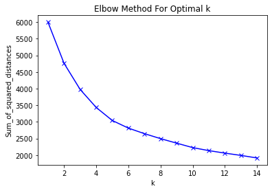

```python
Sum_of_squared_distances = []
K = range(1,15)
for k in K:
    km = KMeans(n_clusters=k)
    km = km.fit(df_pb_std)
    Sum_of_squared_distances.append(km.inertia_)

plt.plot(K, Sum_of_squared_distances, 'bx-')
plt.xlabel('k')
plt.ylabel('Sum_of_squared_distances')
plt.title('Elbow Method For Optimal k')
plt.show()
```

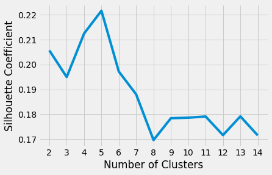

```python
from sklearn.metrics import silhouette_score
from sklearn.cluster import KMeans


silhouette_coefficients = []
K = range(2,15)
for k in K:
    km = KMeans(n_clusters=k)
    km = km.fit(df_pb_std)
    score = silhouette_score(df_pb_std, km.labels_)
    silhouette_coefficients.append(score)

# silhouette_coefficients

plt.style.use("fivethirtyeight")
plt.plot(range(2, 15), silhouette_coefficients)
plt.xticks(range(2, 15))
plt.xlabel("Number of Clusters")
plt.ylabel("Silhouette Coefficient")
plt.show()
```

```python
kmeans = KMeans(
    init="k-means++",
    n_clusters=2,
    n_init=10,
    max_iter=600,
    random_state=42
)

kmeans.fit(df_pb_std)
km2 = kmeans.labels_
```

```python
kmeans = KMeans(
    init="k-means++",
    n_clusters=3,
    n_init=10,
    max_iter=600,
    random_state=42
)

kmeans.fit(df_pb_std)
km3 = kmeans.labels_
```

```python
kmeans = KMeans(
    init="k-means++",
    n_clusters=4,
    n_init=10,
    max_iter=600,
    random_state=42
)

kmeans.fit(df_pb_std)
km4 = kmeans.labels_
```

```python
df_pb['km2'] = km2
df_pb['km3'] = km3
df_pb['km4'] = km4
```

```python
df_pb.km2 = df_pb.km2.map(str)
df_pb.km3 = df_pb.km3.map(str)
df_pb.km4 = df_pb.km4.map(str)
```

Now let's re-attach the demographic Data

```python
df_pb = pd.concat([df_pb, df_user], axis=1)
```

```python
df_pb
```

|  | No. of Brands | Brand Runs | Total Volume | No. of Trans | Value | Trans / Brand Runs | Vol/Tran | Avg. Price | max_value | Others 999 | km2 | km3 | km4 | AGE | EDU | HS | CHILD | Affluence Index | FEH_0 | FEH_1 | FEH_2 | FEH_3 | MT_0 | MT_10 | MT_12 | MT_13 | MT_14 | MT_15 | MT_16 | … |
| --- | --- | --- | --- | --- | --- | --- | --- | --- | --- | --- | --- | --- | --- | --- | --- | --- | --- | --- | --- | --- | --- | --- | --- | --- | --- | --- | --- | --- | --- | --- |
| 0 | 3 | 17 | 8025 | 24 | 818.00 | 1.41 | 334.38 | 10.19 | 0.376947 | 0.492212 | 1 | 2 | 2 | 4 | 4 | 2 | 4 | 2 | 0 | 0 | 0 | 1 | 0 | 1 | 0 | 0 | 0 | 0 | 0 | … |
| 1 | 5 | 25 | 13975 | 40 | 1681.50 | 1.60 | 349.38 | 12.03 | 0.144902 | 0.699463 | 0 | 0 | 1 | 2 | 4 | 4 | 2 | 19 | 0 | 0 | 1 | 0 | 0 | 1 | 0 | 0 | 0 | 0 | 0 | … |
| 2 | 5 | 37 | 23100 | 63 | 1950.00 | 1.70 | 366.67 | 8.44 | 0.545455 | 0.378788 | 0 | 0 | 1 | 4 | 5 | 6 | 4 | 23 | 0 | 0 | 0 | 1 | 0 | 1 | 0 | 0 | 0 | 0 | 0 | … |
| 3 | 2 | 4 | 1500 | 4 | 114.00 | 1.00 | 375.00 | 7.60 | 0.600000 | 0.000000 | 1 | 1 | 0 | 4 | 0 | 0 | 5 | 0 | 1 | 0 | 0 | 0 | 1 | 0 | 0 | 0 | 0 | 0 | 0 | … |
| 4 | 3 | 6 | 8300 | 13 | 591.00 | 2.17 | 638.46 | 7.12 | 0.144578 | 0.807229 | 1 | 2 | 2 | 3 | 4 | 4 | 3 | 10 | 0 | 1 | 0 | 0 | 0 | 1 | 0 | 0 | 0 | 0 | 0 | … |
| ... | ... | ... | ... | ... | ... | ... | ... | ... | ... | ... | ... | ... | ... | ... | ... | ... | ... | ... | ... | ... | ... | ... | ... | ... | ... | ... | ... | ... | ... | … |
| 595 | 3 | 5 | 9025 | 22 | 1218.00 | 4.40 | 410.23 | 13.50 | 0.897507 | 0.058172 | 1 | 1 | 0 | 4 | 5 | 5 | 4 | 15 | 0 | 0 | 0 | 1 | 0 | 1 | 0 | 0 | 0 | 0 | 0 | … |
| 596 | 5 | 23 | 5050 | 28 | 851.00 | 1.22 | 180.36 | 16.85 | 0.103960 | 0.678218 | 0 | 2 | 2 | 3 | 5 | 4 | 4 | 29 | 0 | 0 | 0 | 1 | 0 | 1 | 0 | 0 | 0 | 0 | 0 | … |
| 597 | 4 | 19 | 29100 | 25 | 3302.75 | 1.32 | 1164.00 | 11.35 | 0.246564 | 0.557560 | 0 | 0 | 3 | 4 | 4 | 9 | 4 | 13 | 0 | 0 | 0 | 1 | 0 | 0 | 0 | 0 | 0 | 0 | 0 | … |
| 598 | 3 | 15 | 5500 | 19 | 460.00 | 1.27 | 289.47 | 8.36 | 0.109091 | 0.863636 | 0 | 2 | 2 | 4 | 5 | 2 | 4 | 20 | 0 | 1 | 0 | 0 | 0 | 0 | 0 | 0 | 0 | 0 | 0 | … |
| 599 | 3 | 9 | 12300 | 14 | 1385.00 | 1.56 | 878.57 | 11.26 | 0.577236 | 0.186992 | 1 | 1 | 0 | 4 | 4 | 6 | 4 | 15 | 0 | 0 | 0 | 1 | 0 | 1 | 0 | 0 | 0 | 0 | 0 | … |

600 rows × 40 columns

```python
km2_pb = df_pb.groupby('km2').mean()
km3_pb = df_pb.groupby('km3').mean()
km4_pb = df_pb.groupby('km4').mean()
```

### K = 2

```python
df_pb.km2.value_counts()
```

```
0    317
1    283
Name: km2, dtype: int64
```

```python
df_pb.km2.value_counts() / 600
```

```
0    0.528333
1    0.471667
Name: km2, dtype: float64
```

```python
km2_pb
```

| km2 | No. of Brands | Brand Runs | Total Volume | No. of Trans | Value | Trans / Brand Runs | Vol/Tran | Avg. Price | max_value | Others 999 | AGE | EDU | HS | CHILD | Affluence Index | FEH_0 | FEH_1 | FEH_2 | FEH_3 | MT_0 | MT_10 | MT_12 | MT_13 | MT_14 | MT_15 | MT_16 | MT_17 | MT_19 | MT_3 | … |
| --- | --- | --- | --- | --- | --- | --- | --- | --- | --- | --- | --- | --- | --- | --- | --- | --- | --- | --- | --- | --- | --- | --- | --- | --- | --- | --- | --- | --- | --- | --- |
| 0 | 4.400631 | 22.331230 | 13144.217666 | 40.252366 | 1608.479527 | 1.937224 | 344.058991 | 12.881514 | 0.203468 | 0.667362 | 3.296530 | 4.665615 | 4.523659 | 3.041009 | 20.801262 | 0.041009 | 0.299685 | 0.053628 | 0.605678 | 0.041009 | 0.570978 | 0.012618 | 0.015773 | 0.006309 | 0.022082 | 0.018927 | 0.044164 | 0.000000 | 0.006309 | … |
| 1 | 2.780919 | 8.381625 | 10537.614841 | 20.961131 | 1033.723852 | 3.380106 | 494.572544 | 10.662155 | 0.559117 | 0.359157 | 3.120141 | 3.346290 | 3.819788 | 3.448763 | 12.784452 | 0.197880 | 0.247350 | 0.060071 | 0.494700 | 0.197880 | 0.512367 | 0.010601 | 0.010601 | 0.003534 | 0.003534 | 0.014134 | 0.038869 | 0.003534 | 0.010601 | … |

### K = 3

```python
df_pb.km3.value_counts()
```

```
2    259
1    175
0    166
Name: km3, dtype: int64
```

```python
df_pb.km3.value_counts() / 600
```

```
2    0.431667
1    0.291667
0    0.276667
Name: km3, dtype: float64
```

```python
km3_pb
```

| km3 | No. of Brands | Brand Runs | Total Volume | No. of Trans | Value | Trans / Brand Runs | Vol/Tran | Avg. Price | max_value | Others 999 | AGE | EDU | HS | CHILD | Affluence Index | FEH_0 | FEH_1 | FEH_2 | FEH_3 | MT_0 | MT_10 | MT_12 | MT_13 | MT_14 | MT_15 | MT_16 | MT_17 | MT_19 | MT_3 | … |
| --- | --- | --- | --- | --- | --- | --- | --- | --- | --- | --- | --- | --- | --- | --- | --- | --- | --- | --- | --- | --- | --- | --- | --- | --- | --- | --- | --- | --- | --- | --- |
| 0 | 5.138554 | 27.180723 | 16856.536145 | 50.012048 | 2015.039759 | 1.954096 | 367.734639 | 12.311325 | 0.235052 | 0.597753 | 3.349398 | 4.60241 | 5.108434 | 2.963855 | 20.993976 | 0.024096 | 0.253012 | 0.060241 | 0.662651 | 0.024096 | 0.626506 | 0.018072 | 0.006024 | 0.006024 | 0.024096 | 0.012048 | 0.048193 | 0.000000 | 0.000000 | … |
| 1 | 2.857143 | 8.228571 | 13349.428571 | 23.982857 | 1289.289714 | 4.200743 | 560.664457 | 10.117886 | 0.725076 | 0.186530 | 3.205714 | 3.52000 | 4.382857 | 3.371429 | 13.862857 | 0.131429 | 0.245714 | 0.068571 | 0.554286 | 0.131429 | 0.554286 | 0.005714 | 0.000000 | 0.000000 | 0.005714 | 0.017143 | 0.045714 | 0.005714 | 0.011429 | … |
| 2 | 3.200772 | 13.509653 | 7778.096525 | 23.911197 | 935.558147 | 1.973591 | 346.990347 | 12.689266 | 0.219392 | 0.700098 | 3.131274 | 4.03861 | 3.474903 | 3.312741 | 16.606178 | 0.162162 | 0.308880 | 0.046332 | 0.482625 | 0.162162 | 0.482625 | 0.011583 | 0.027027 | 0.007722 | 0.011583 | 0.019305 | 0.034749 | 0.000000 | 0.011583 | … |

### K = 4

```python
df_pb.km4.value_counts()
```

```
2    203
0    176
1    176
3     45
Name: km4, dtype: int64
```

```python
df_pb.km4.value_counts() / 600
```

```
2    0.338333
0    0.293333
1    0.293333
3    0.075000
Name: km4, dtype: float64
```

```python
km4_pb
```

| km4 | No. of Brands | Brand Runs | Total Volume | No. of Trans | Value | Trans / Brand Runs | Vol/Tran | Avg. Price | max_value | Others 999 | AGE | EDU | HS | CHILD | Affluence Index | FEH_0 | FEH_1 | FEH_2 | FEH_3 | MT_0 | MT_10 | MT_12 | MT_13 | MT_14 | MT_15 | MT_16 | MT_17 | MT_19 | MT_3 | … |
| --- | --- | --- | --- | --- | --- | --- | --- | --- | --- | --- | --- | --- | --- | --- | --- | --- | --- | --- | --- | --- | --- | --- | --- | --- | --- | --- | --- | --- | --- | --- |
| 0 | 2.965909 | 8.267045 | 10262.102273 | 22.630682 | 1000.982670 | 3.953295 | 460.663239 | 10.404318 | 0.721922 | 0.182069 | 3.113636 | 3.528409 | 3.914773 | 3.460227 | 13.897727 | 0.159091 | 0.278409 | 0.062500 | 0.500000 | 0.159091 | 0.528409 | 0.017045 | 0.000000 | 0.000000 | 0.005682 | 0.017045 | 0.028409 | 0.005682 | 0.011364 | … |
| 1 | 5.227273 | 26.909091 | 13496.090909 | 47.954545 | 1642.597216 | 1.875625 | 293.985568 | 12.538352 | 0.236212 | 0.590505 | 3.318182 | 4.835227 | 4.664773 | 2.988636 | 21.448864 | 0.022727 | 0.301136 | 0.062500 | 0.613636 | 0.022727 | 0.607955 | 0.022727 | 0.011364 | 0.011364 | 0.022727 | 0.011364 | 0.017045 | 0.000000 | 0.005682 | … |
| 2 | 2.866995 | 12.556650 | 7964.852217 | 22.827586 | 952.166010 | 2.051084 | 365.096749 | 12.744286 | 0.178157 | 0.757313 | 3.152709 | 3.768473 | 3.458128 | 3.325123 | 15.443350 | 0.182266 | 0.270936 | 0.049261 | 0.497537 | 0.182266 | 0.492611 | 0.000000 | 0.029557 | 0.004926 | 0.014778 | 0.024631 | 0.044335 | 0.000000 | 0.009852 | … |
| 3 | 3.511111 | 15.800000 | 30012.333333 | 36.333333 | 3197.157778 | 2.853556 | 935.508889 | 10.574000 | 0.398488 | 0.521946 | 3.466667 | 4.200000 | 6.733333 | 2.888889 | 19.022222 | 0.000000 | 0.177778 | 0.044444 | 0.777778 | 0.000000 | 0.577778 | 0.000000 | 0.000000 | 0.000000 | 0.000000 | 0.000000 | 0.177778 | 0.000000 | 0.000000 | … |

# Clustering the Basis for Purchase Data

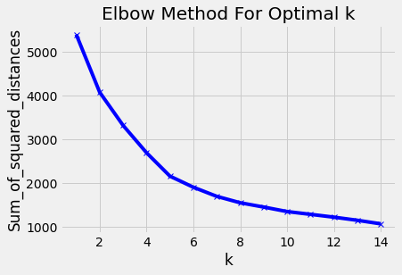

```python
Sum_of_squared_distances = []
K = range(1,15)
for k in K:
    km = KMeans(n_clusters=k)
    km = km.fit(df_bfp_std)
    Sum_of_squared_distances.append(km.inertia_)

plt.plot(K, Sum_of_squared_distances, 'bx-')
plt.xlabel('k')
plt.ylabel('Sum_of_squared_distances')
plt.title('Elbow Method For Optimal k')
plt.show()
```

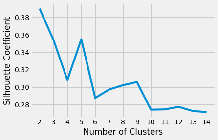

```python
silhouette_coefficients = []
K = range(2,15)
for k in K:
    km = KMeans(n_clusters=k)
    km = km.fit(df_bfp_std)
    score = silhouette_score(df_bfp_std, km.labels_)
    silhouette_coefficients.append(score)

# silhouette_coefficients

plt.style.use("fivethirtyeight")
plt.plot(range(2, 15), silhouette_coefficients)
plt.xticks(range(2, 15))
plt.xlabel("Number of Clusters")
plt.ylabel("Silhouette Coefficient")
plt.show()
```

```python
kmeans = KMeans(
    init="k-means++",
    n_clusters=2,
    n_init=10,
    max_iter=600,
    random_state=42
)

kmeans.fit(df_bfp_std)
km2 = kmeans.labels_
```

```python
kmeans = KMeans(
    init="k-means++",
    n_clusters=3,
    n_init=10,
    max_iter=600,
    random_state=42
)


kmeans.fit(df_bfp_std)
km3 = kmeans.labels_
```

```python
kmeans = KMeans(
    init="k-means++",
    n_clusters=4,
    n_init=10,
    max_iter=600,
    random_state=42
)

kmeans.fit(df_bfp_std)
km4 = kmeans.labels_
```

```python
df_bfp['km2'] = km2
df_bfp['km3'] = km3
df_bfp['km4'] = km4
```

```python
df_bfp.km2 = df_bfp.km2.map(str)
df_bfp.km3 = df_bfp.km3.map(str)
df_bfp.km4 = df_bfp.km4.map(str)
```

```python
df_bfp = pd.concat([df_bfp, df_user], axis=1)
```

```python
km2_bfp = df_bfp.groupby('km2').mean()
km3_bfp = df_bfp.groupby('km3').mean()
km4_bfp = df_bfp.groupby('km4').mean()
```

### K = 2

```python
df_bfp.km2.value_counts()
```

```
1    523
0     77
Name: km2, dtype: int64
```

```python
df_bfp.km2.value_counts() / 600
```

```
1    0.871667
0    0.128333
Name: km2, dtype: float64
```

```python
km2_bfp
```

| km2 | Pur Vol No Promo - % | Pur Vol Promo 6 % | Pur Vol Other Promo % | Pr Cat 1 | Pr Cat 2 | Pr Cat 3 | Pr Cat 4 | PropCat 5 | PropCat 14 | AGE | EDU | HS | CHILD | Affluence Index | FEH_0 | FEH_1 | FEH_2 | FEH_3 | MT_0 | MT_10 | MT_12 | MT_13 | MT_14 | MT_15 | MT_16 | MT_17 | MT_19 | MT_3 | MT_4 | … |
| --- | --- | --- | --- | --- | --- | --- | --- | --- | --- | --- | --- | --- | --- | --- | --- | --- | --- | --- | --- | --- | --- | --- | --- | --- | --- | --- | --- | --- | --- | --- |
| 0 | 0.937553 | 0.016065 | 0.046383 | 0.056637 | 0.139771 | 0.779123 | 0.024468 | 0.107368 | 0.772817 | 3.025974 | 2.519481 | 4.220779 | 3.480519 | 9.103896 | 0.194805 | 0.129870 | 0.051948 | 0.623377 | 0.194805 | 0.584416 | 0.012987 | 0.000000 | 0.000000 | 0.012987 | 0.038961 | 0.025974 | 0.000000 | 0.00000 | 0.077922 | … |
| 1 | 0.909395 | 0.059012 | 0.031594 | 0.311780 | 0.545167 | 0.044990 | 0.098062 | 0.508663 | 0.042794 | 3.240918 | 4.267686 | 4.187380 | 3.196941 | 18.185468 | 0.103250 | 0.296367 | 0.057361 | 0.543021 | 0.103250 | 0.537285 | 0.011472 | 0.015296 | 0.005736 | 0.013384 | 0.013384 | 0.043977 | 0.001912 | 0.00956 | 0.147228 | … |

### K = 3

```python
df_bfp.km3.value_counts()
```

```
0    429
1     97
2     74
Name: km3, dtype: int64
```

```python
df_bfp.km3.value_counts() / 600
```

```
0    0.715000
1    0.161667
2    0.123333
Name: km3, dtype: float64
```

```python
km3_bfp
```

| km3 | Pur Vol No Promo - % | Pur Vol Promo 6 % | Pur Vol Other Promo % | Pr Cat 1 | Pr Cat 2 | Pr Cat 3 | Pr Cat 4 | PropCat 5 | PropCat 14 | AGE | EDU | HS | CHILD | Affluence Index | FEH_0 | FEH_1 | FEH_2 | FEH_3 | MT_0 | MT_10 | MT_12 | MT_13 | MT_14 | MT_15 | MT_16 | MT_17 | MT_19 | MT_3 | MT_4 | … |
| --- | --- | --- | --- | --- | --- | --- | --- | --- | --- | --- | --- | --- | --- | --- | --- | --- | --- | --- | --- | --- | --- | --- | --- | --- | --- | --- | --- | --- | --- | --- |
| 0 | 0.954789 | 0.026726 | 0.018486 | 0.296713 | 0.573789 | 0.049103 | 0.080394 | 0.519053 | 0.047107 | 3.223776 | 4.221445 | 4.174825 | 3.144522 | 17.615385 | 0.109557 | 0.275058 | 0.065268 | 0.550117 | 0.109557 | 0.540793 | 0.009324 | 0.013986 | 0.006993 | 0.011655 | 0.011655 | 0.044289 | 0.002331 | 0.011655 | 0.137529 | … |
| 1 | 0.704829 | 0.202752 | 0.092419 | 0.372906 | 0.410384 | 0.040239 | 0.176471 | 0.457829 | 0.037229 | 3.298969 | 4.484536 | 4.237113 | 3.422680 | 20.567010 | 0.072165 | 0.391753 | 0.020619 | 0.515464 | 0.072165 | 0.525773 | 0.020619 | 0.020619 | 0.000000 | 0.020619 | 0.020619 | 0.041237 | 0.000000 | 0.000000 | 0.185567 | … |
| 2 | 0.943679 | 0.013077 | 0.043244 | 0.053515 | 0.134083 | 0.791269 | 0.021133 | 0.097505 | 0.784708 | 3.040541 | 2.432432 | 4.229730 | 3.500000 | 8.918919 | 0.202703 | 0.121622 | 0.054054 | 0.621622 | 0.202703 | 0.581081 | 0.013514 | 0.000000 | 0.000000 | 0.013514 | 0.040541 | 0.027027 | 0.000000 | 0.000000 | 0.081081 | … |

### K = 4

```python
df_bfp.km4.value_counts()
```

```
2    310
0    124
1     91
3     75
Name: km4, dtype: int64
```

```python
df_bfp.km4.value_counts() / 600
```

```
2    0.516667
0    0.206667
1    0.151667
3    0.125000
Name: km4, dtype: float64
```

```python
km4_bfp
```

| km4 | Pur Vol No Promo - % | Pur Vol Promo 6 % | Pur Vol Other Promo % | Pr Cat 1 | Pr Cat 2 | Pr Cat 3 | Pr Cat 4 | PropCat 5 | PropCat 14 | AGE | EDU | HS | CHILD | Affluence Index | FEH_0 | FEH_1 | FEH_2 | FEH_3 | MT_0 | MT_10 | MT_12 | MT_13 | MT_14 | MT_15 | MT_16 | MT_17 | MT_19 | MT_3 | MT_4 | … |
| --- | --- | --- | --- | --- | --- | --- | --- | --- | --- | --- | --- | --- | --- | --- | --- | --- | --- | --- | --- | --- | --- | --- | --- | --- | --- | --- | --- | --- | --- | --- |
| 0 | 0.934180 | 0.034813 | 0.031007 | 0.734944 | 0.233912 | 0.014499 | 0.016645 | 0.325784 | 0.014396 | 3.258065 | 4.483871 | 3.645161 | 3.346774 | 20.491935 | 0.169355 | 0.298387 | 0.056452 | 0.475806 | 0.169355 | 0.435484 | 0.008065 | 0.016129 | 0.008065 | 0.024194 | 0.024194 | 0.016129 | 0.000000 | 0.024194 | 0.120968 | … |
| 1 | 0.731088 | 0.191706 | 0.077206 | 0.243024 | 0.374384 | 0.039778 | 0.342814 | 0.586265 | 0.034295 | 3.318681 | 4.098901 | 4.307692 | 3.395604 | 17.648352 | 0.098901 | 0.340659 | 0.032967 | 0.527473 | 0.098901 | 0.516484 | 0.010989 | 0.010989 | 0.000000 | 0.010989 | 0.021978 | 0.087912 | 0.000000 | 0.000000 | 0.164835 | … |
| 2 | 0.951425 | 0.030227 | 0.018348 | 0.160985 | 0.718393 | 0.061440 | 0.059183 | 0.557640 | 0.059385 | 3.209677 | 4.238710 | 4.367742 | 3.077419 | 17.380645 | 0.077419 | 0.280645 | 0.064516 | 0.577419 | 0.077419 | 0.587097 | 0.012903 | 0.016129 | 0.006452 | 0.009677 | 0.006452 | 0.041935 | 0.003226 | 0.006452 | 0.151613 | … |
| 3 | 0.939944 | 0.012902 | 0.047154 | 0.056913 | 0.134788 | 0.787448 | 0.020851 | 0.102435 | 0.780974 | 3.026667 | 2.440000 | 4.226667 | 3.493333 | 9.026667 | 0.200000 | 0.133333 | 0.053333 | 0.613333 | 0.200000 | 0.573333 | 0.013333 | 0.000000 | 0.000000 | 0.013333 | 0.040000 | 0.026667 | 0.000000 | 0.000000 | 0.080000 | … |

# Clustering Using Both Purchase Basis and Behaviour Features

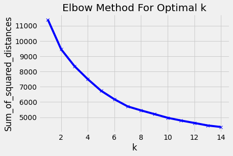

```python
Sum_of_squared_distances = []
K = range(1,15)
for k in K:
    km = KMeans(n_clusters=k)
    km = km.fit(df_all_std)
    Sum_of_squared_distances.append(km.inertia_)

plt.plot(K, Sum_of_squared_distances, 'bx-')
plt.xlabel('k')
plt.ylabel('Sum_of_squared_distances')
plt.title('Elbow Method For Optimal k')
plt.show()
```

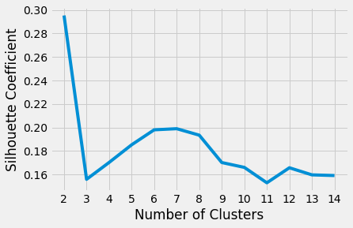

```python
silhouette_coefficients = []
K = range(2,15)
for k in K:
    km = KMeans(n_clusters=k)
    km = km.fit(df_all_std)
    score = silhouette_score(df_all_std, km.labels_)
    silhouette_coefficients.append(score)

# silhouette_coefficients

plt.style.use("fivethirtyeight")
plt.plot(range(2, 15), silhouette_coefficients)
plt.xticks(range(2, 15))
plt.xlabel("Number of Clusters")
plt.ylabel("Silhouette Coefficient")
plt.show()
```

```python
kmeans = KMeans(
    init="k-means++",
    n_clusters=2,
    n_init=10,
    max_iter=600,
    random_state=42
)

kmeans.fit(df_all_std)
km2 = kmeans.labels_
```

```python
kmeans = KMeans(
    init="k-means++",
    n_clusters=3,
    n_init=10,
    max_iter=600,
    random_state=42
)

kmeans.fit(df_all_std)
km3 = kmeans.labels_
```

```python
kmeans = KMeans(
    init="k-means++",
    n_clusters=4,
    n_init=10,
    max_iter=600,
    random_state=42
)

kmeans.fit(df_all_std)
km4 = kmeans.labels_
```

```python
df_all['km2'] = km2
df_all['km3'] = km3
df_all['km4'] = km4
```

```python
df_all.km2 = df_all.km2.map(str)
df_all.km3 = df_all.km3.map(str)
df_all.km4 = df_all.km4.map(str)
```

```python
df_all = pd.concat([df_all, df_user], axis=1)
```

```python
km2_all = df_all.groupby('km2').mean()
km3_all = df_all.groupby('km3').mean()
km4_all = df_all.groupby('km4').mean()
```

```python
df_all.km2.value_counts()
```

```
0    528
1     72
Name: km2, dtype: int64
```

```python
df_all.km2.value_counts() / 600
```

```
0    0.88
1    0.12
Name: km2, dtype: float64
```

```python
km2_all
```

| km2 | No. of Brands | Brand Runs | Total Volume | No. of Trans | Value | Trans / Brand Runs | Vol/Tran | Avg. Price | max_value | Others 999 | Pur Vol No Promo - % | Pur Vol Promo 6 % | Pur Vol Other Promo % | Pr Cat 1 | Pr Cat 2 | Pr Cat 3 | Pr Cat 4 | PropCat 5 | PropCat 14 | AGE | EDU | HS | CHILD | Affluence Index | FEH_0 | FEH_1 | FEH_2 | FEH_3 | MT_0 | … |
| --- | --- | --- | --- | --- | --- | --- | --- | --- | --- | --- | --- | --- | --- | --- | --- | --- | --- | --- | --- | --- | --- | --- | --- | --- | --- | --- | --- | --- | --- | --- |
| 0 | 3.757576 | 16.871212 | 11777.456439 | 32.159091 | 1399.589886 | 2.243561 | 396.415303 | 12.501875 | 0.315935 | 0.573005 | 0.909886 | 0.058744 | 0.031370 | 0.309754 | 0.543051 | 0.049993 | 0.097202 | 0.506227 | 0.047818 | 3.246212 | 4.268939 | 4.198864 | 3.202652 | 18.159091 | 0.102273 | 0.293561 | 0.056818 | 0.547348 | 0.102273 | … |
| 1 | 2.750000 | 7.541667 | 12921.736111 | 23.777778 | 881.227778 | 5.362083 | 551.714583 | 6.942222 | 0.776608 | 0.147897 | 0.935903 | 0.015046 | 0.049051 | 0.053778 | 0.127143 | 0.793416 | 0.025664 | 0.097371 | 0.786672 | 2.972222 | 2.388889 | 4.138889 | 3.458333 | 8.666667 | 0.208333 | 0.138889 | 0.055556 | 0.597222 | 0.208333 | … |

```python
df_all.km3.value_counts()
```

```
0    287
2    241
1     72
Name: km3, dtype: int64
```

```python
df_all.km3.value_counts() /600
```

```
0    0.478333
2    0.401667
1    0.120000
Name: km3, dtype: float64
```

```python
km3_all
```

| km3 | No. of Brands | Brand Runs | Total Volume | No. of Trans | Value | Trans / Brand Runs | Vol/Tran | Avg. Price | max_value | Others 999 | Pur Vol No Promo - % | Pur Vol Promo 6 % | Pur Vol Other Promo % | Pr Cat 1 | Pr Cat 2 | Pr Cat 3 | Pr Cat 4 | PropCat 5 | PropCat 14 | AGE | EDU | HS | CHILD | Affluence Index | FEH_0 | FEH_1 | FEH_2 | FEH_3 | MT_0 | … |
| --- | --- | --- | --- | --- | --- | --- | --- | --- | --- | --- | --- | --- | --- | --- | --- | --- | --- | --- | --- | --- | --- | --- | --- | --- | --- | --- | --- | --- | --- | --- |
| 0 | 4.278746 | 21.731707 | 11110.139373 | 38.651568 | 1464.963589 | 1.990801 | 297.177003 | 13.896934 | 0.211480 | 0.663211 | 0.880176 | 0.085336 | 0.034488 | 0.460380 | 0.430348 | 0.038706 | 0.070566 | 0.389438 | 0.036803 | 3.261324 | 4.637631 | 4.114983 | 3.177700 | 20.857143 | 0.087108 | 0.306620 | 0.062718 | 0.543554 | 0.087108 | … |
| 1 | 2.833333 | 7.833333 | 12980.069444 | 24.347222 | 883.818056 | 5.234722 | 544.563194 | 6.930278 | 0.769639 | 0.150833 | 0.936532 | 0.015046 | 0.048422 | 0.055072 | 0.117793 | 0.801352 | 0.025783 | 0.100665 | 0.794608 | 3.000000 | 2.347222 | 4.125000 | 3.486111 | 8.694444 | 0.208333 | 0.138889 | 0.055556 | 0.597222 | 0.208333 | … |
| 2 | 3.112033 | 10.995851 | 12554.717842 | 24.257261 | 1320.964357 | 2.582614 | 516.731867 | 10.844108 | 0.442410 | 0.464705 | 0.945079 | 0.027076 | 0.027844 | 0.129990 | 0.680058 | 0.061064 | 0.128887 | 0.644322 | 0.058565 | 3.219917 | 3.842324 | 4.302905 | 3.224066 | 14.937759 | 0.120332 | 0.278008 | 0.049793 | 0.551867 | 0.120332 | … |

```python
df_all.km4.value_counts()
```

```
2    220
1    201
0    109
3     70
Name: km4, dtype: int64
```

```python
df_all.km4.value_counts() / 600
```

```
2    0.366667
1    0.335000
0    0.181667
3    0.116667
Name: km4, dtype: float64
```

```python
km4_all
```

| km4 | No. of Brands | Brand Runs | Total Volume | No. of Trans | Value | Trans / Brand Runs | Vol/Tran | Avg. Price | max_value | Others 999 | Pur Vol No Promo - % | Pur Vol Promo 6 % | Pur Vol Other Promo % | Pr Cat 1 | Pr Cat 2 | Pr Cat 3 | Pr Cat 4 | PropCat 5 | PropCat 14 | AGE | EDU | HS | CHILD | Affluence Index | FEH_0 | FEH_1 | FEH_2 | FEH_3 | MT_0 | … |
| --- | --- | --- | --- | --- | --- | --- | --- | --- | --- | --- | --- | --- | --- | --- | --- | --- | --- | --- | --- | --- | --- | --- | --- | --- | --- | --- | --- | --- | --- | --- |
| 0 | 2.981651 | 12.440367 | 6848.669725 | 23.715596 | 1144.229817 | 2.252661 | 300.876697 | 16.917890 | 0.251894 | 0.674822 | 0.935402 | 0.037158 | 0.027440 | 0.740225 | 0.238212 | 0.010808 | 0.010755 | 0.343856 | 0.010772 | 3.165138 | 4.165138 | 3.045872 | 3.550459 | 18.018349 | 0.247706 | 0.266055 | 0.055046 | 0.431193 | 0.247706 | … |
| 1 | 4.960199 | 25.875622 | 14175.074627 | 45.522388 | 1680.602239 | 1.838259 | 325.249552 | 12.072239 | 0.213600 | 0.631434 | 0.855899 | 0.107870 | 0.036231 | 0.291956 | 0.536847 | 0.067436 | 0.103761 | 0.432322 | 0.064408 | 3.323383 | 4.626866 | 4.681592 | 3.044776 | 20.930348 | 0.029851 | 0.308458 | 0.059701 | 0.601990 | 0.029851 | … |
| 2 | 3.045455 | 10.790909 | 12153.531818 | 24.113636 | 1275.642545 | 2.651273 | 512.994455 | 10.669091 | 0.445350 | 0.465873 | 0.946099 | 0.024822 | 0.029079 | 0.109986 | 0.700540 | 0.055563 | 0.133911 | 0.651047 | 0.053127 | 3.200000 | 3.986364 | 4.400000 | 3.159091 | 15.650000 | 0.095455 | 0.295455 | 0.054545 | 0.554545 | 0.095455 | … |
| 3 | 2.714286 | 7.428571 | 12562.714286 | 23.600000 | 846.691429 | 5.319429 | 542.874714 | 6.900857 | 0.776607 | 0.146134 | 0.938127 | 0.012957 | 0.048916 | 0.055106 | 0.112784 | 0.808084 | 0.024026 | 0.095585 | 0.801147 | 3.014286 | 2.357143 | 3.914286 | 3.514286 | 8.542857 | 0.214286 | 0.128571 | 0.057143 | 0.600000 | 0.214286 | … |

# Second Part

Importing cluster in the original dataframe

```python
df['cluster'] = df_all[['km3']]
```

Let's have a look to the distribution of 0 and 1 in the variable

```python
# check the distribution
df['cluster'].value_counts()/df.shape[0]
```

```
0    0.478333
2    0.401667
1    0.120000
Name: cluster, dtype: float64
```

Since our target is the cluster number "1", we're going to set as "0" the cluster number 2 in order to obtain a binary variable (Loyal and ot loyal people)

```python
df["cluster"].replace({"2": "0"}, inplace=True)
df['cluster'].value_counts()
```

```
0    528
1     72
Name: cluster, dtype: int64
```

The data are very unbalanced. Let's try to visualize the 1s

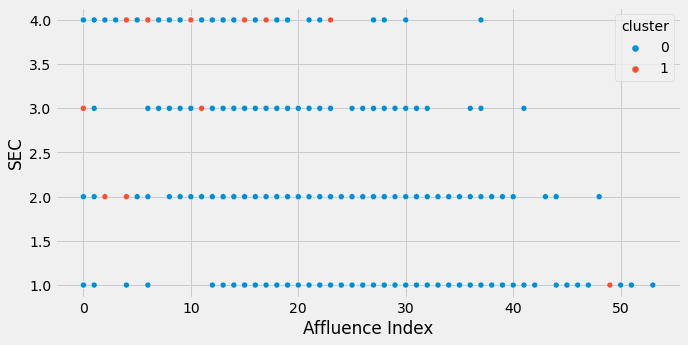

```python
# scatter plot

import seaborn as sns

plt.figure(figsize=(10,5))
sns.scatterplot(data=df,x='Affluence Index',y='SEC',hue='cluster')
```

# Logit Model

First let's standardize the DF and create train, test, validation df

```python
y = df.cluster
X = df[['SEC', 'AGE', 'EDU', 'HS', 'CHILD', 'Affluence Index', 'FEH_0', 'FEH_1', 'FEH_2',
       'FEH_3',  'SEX_0', 'SEX_1', 'SEX_2', 'CS_0', 'CS_1', 'CS_2']]

from sklearn.preprocessing import StandardScaler, MinMaxScaler
from sklearn.model_selection import train_test_split

# standardize the dataset
scaler = StandardScaler()
X_scaled = scaler.fit_transform(X)
```

```python
X_train, X_temp, y_train, y_temp = train_test_split(X_scaled, y, stratify=y, test_size=0.3, random_state=42)
X_val, X_test, y_val, y_test = train_test_split(X_temp, y_temp, stratify=y_temp, test_size=0.70, random_state=42)
print('obs in train data:', X_train.shape[0],', obs in validation data:',
      X_val.shape[0], ', obs in test data:', X_test.shape[0] )
```

```
obs in train data: 420 , obs in validation data: 54 , obs in test data: 126
```

```python
from sklearn.ensemble import RandomForestClassifier
from sklearn.linear_model import LogisticRegressionCV
from sklearn.model_selection import train_test_split
from sklearn.model_selection import StratifiedShuffleSplit
from sklearn.metrics import accuracy_score
```

```python
# import model and matrics
from sklearn.linear_model import LogisticRegression
from sklearn.model_selection import train_test_split, GridSearchCV, cross_val_score, RepeatedStratifiedKFold, StratifiedKFold
from sklearn.metrics import accuracy_score, confusion_matrix,roc_curve, roc_auc_score, precision_score, recall_score, precision_recall_curve
from sklearn.metrics import f1_score
from sklearn import metrics
import numpy as np
```

Let's build a logistic model with the standard parameters

```
Accuracy Score: 0.8888888888888888
Confusion Matrix:
[[109   2]
 [ 12   3]]
Area Under Curve: 0.590990990990991
```

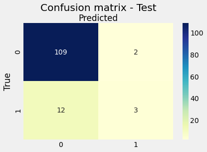

```python
# define model
lg1 = LogisticRegression(random_state=13, class_weight=None)
# fit it
lg1.fit(X_train,y_train)
# test
y_pred = lg1.predict(X_test)
# performance
print(f'Accuracy Score: {accuracy_score(y_test,y_pred)}')
print(f'Confusion Matrix: \n{confusion_matrix(y_test, y_pred)}')
print(f'Area Under Curve: {roc_auc_score(y_test, y_pred)}')

cnf_matrix = metrics.confusion_matrix(y_test, y_pred)

labels = [0, 1]
fig, ax = plt.subplots()
tick_marks = np.arange(len(labels))
plt.xticks(tick_marks, labels)
plt.yticks(tick_marks, labels)
# create heatmap
sns.heatmap(pd.DataFrame(cnf_matrix), annot=True, cmap="YlGnBu", fmt='g')
ax.xaxis.set_label_position("top")
plt.title('Confusion matrix - Test', y=1.1)
plt.ylabel('True')
plt.xlabel('Predicted')
```

```python
y_prob = lg1.predict_proba(X_test)
y_test2= '1' <= y_test
```

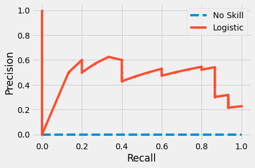

```python
from sklearn.metrics import precision_recall_curve
from matplotlib import pyplot

#Making y_test a Boolean vector
# y_test= '1' <= y_test

# calculate the no skill line as the proportion of the positive class
no_skill = len(y[y==1]) / len(y)
# plot the no skill precision-recall curve
pyplot.plot([0, 1], [no_skill, no_skill], linestyle='--', label='No Skill')
# calculate model precision-recall curve
precision, recall, _ = precision_recall_curve(y_test2.values, y_prob[:, 1]
)
# plot the model precision-recall curve
pyplot.plot(recall, precision, marker='.', label='Logistic')
# axis labels
pyplot.xlabel('Recall')
pyplot.ylabel('Precision')
# show the legend
pyplot.legend()
# show the plot
pyplot.show()
```

```python
from sklearn.metrics import auc
auc_score = auc(recall, precision)
auc_score
```

```
0.45591673374678854
```

# Logistic Regression with weights

Let's try to build a logistic model with weights. Weights are useful when dealing with unbalanced data.

In case be unbalanced label distribution, the best practice for weights is to use the inverse of the label distribution. In our set, label distribution the ratio between 0s and 1s is 1:7.3, so we can specify weights as inverse of label distribution. We can do this using class_weight='balanced'.

For majority class, will use weight of 1 and for minority class, will use weight of 7.3. So the penalty of wrong prediction of minority class would be 7.3 times more severe than wrong prediction of majority class. Moreover, with this class-weight values, we would expect our model to perform better then the default one i.e. previous model.

https://towardsdatascience.com/weighted-logistic-regression-for-imbalanced-dataset-9a5cd88e68b

```python
# import model and matrics
from sklearn.linear_model import LogisticRegression
from sklearn.model_selection import train_test_split, GridSearchCV, cross_val_score, RepeatedStratifiedKFold, StratifiedKFold
from sklearn.metrics import accuracy_score, confusion_matrix,roc_curve, roc_auc_score, precision_score, recall_score, precision_recall_curve
from sklearn.metrics import f1_score
```

```python
lg2 = LogisticRegression(class_weight='balanced')
# fit it
lg2.fit(X_train,y_train)
# test
y_pred = lg2.predict(X_test)
# performance
print(f'Accuracy Score: {accuracy_score(y_test,y_pred)}')
print(f'Confusion Matrix: \n{confusion_matrix(y_test, y_pred)}')
print(f'Area Under Curve: {roc_auc_score(y_test, y_pred)}')
```

```
Accuracy Score: 0.7619047619047619
Confusion Matrix:
[[83 28]
 [ 2 13]]
Area Under Curve: 0.8072072072072072
```

We can improve our model adjusting the threshold. By default, The model classify as 1 all the observations with a probability above 0.5. Adjusting this threshold may be possible to improve the accuracy of the model.

https://machinelearningmastery.com/threshold-moving-for-imbalanced-classification/

```python
# search thresholds for imbalanced classification
from numpy import arange
from numpy import argmax
from sklearn.datasets import make_classification
from sklearn.linear_model import LogisticRegression
from sklearn.model_selection import train_test_split
from sklearn.metrics import f1_score

# apply threshold to positive probabilities to create labels
def to_labels(pos_probs, threshold):
    return (pos_probs >= threshold).astype('int')


# predict probabilities
yhat = lg2.predict_proba(X_test)
# keep probabilities for the positive outcome only
probs = yhat[:, 1]
# define thresholds
thresholds = arange(0, 1, 0.01)
a = y_test.values
a = a.astype('int')
# evaluate each threshold
scores = [f1_score(a, to_labels(probs, t)) for t in thresholds]
# get best threshold
ix = argmax(scores)
print('Threshold=%.3f, F-Score=%.5f' % (thresholds[ix], scores[ix]))
```

```
Threshold=0.660, F-Score=0.63415
```

```python
new_pred = to_labels(probs, 0.66)
```

```python
confusion_matrix(a, new_pred)
```

```
array([[98, 13],
       [ 2, 13]], dtype=int64)
```

# Performance on Test Set

Since we are interested in estimating the 1s, we cannot use the accuracy as a Metric. When dealing with Imbalanced datasets, the number of 0s is way more then the number of 1s. Because of this, a model that predict always "no" may have a high accuracy, but it's not able to predict the 1s. We want to find the best model for predicting the 1s.

Because of this we need to look the F1-score, precision and recall

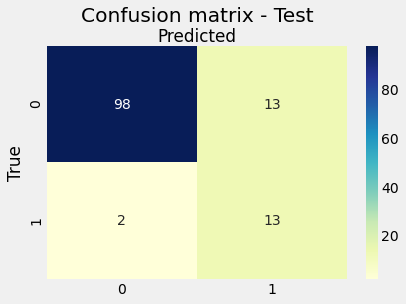

```python
from sklearn.metrics import accuracy_score
import sklearn.metrics as metrics
import numpy as np

cnf_matrix = metrics.confusion_matrix(a, new_pred)

labels = [0, 1]
fig, ax = plt.subplots()
tick_marks = np.arange(len(labels))
plt.xticks(tick_marks, labels)
plt.yticks(tick_marks, labels)
# create heatmap
sns.heatmap(pd.DataFrame(cnf_matrix), annot=True, cmap="YlGnBu", fmt='g')
ax.xaxis.set_label_position("top")
plt.title('Confusion matrix - Test', y=1.1)
plt.ylabel('True')
plt.xlabel('Predicted')
```

```python
print('Accuracy score on Test Set:', accuracy_score(a, new_pred))
```

```
Accuracy score on Test Set: 0.8809523809523809
```

```python
f1_score(a, new_pred)
```

```
0.6341463414634146
```

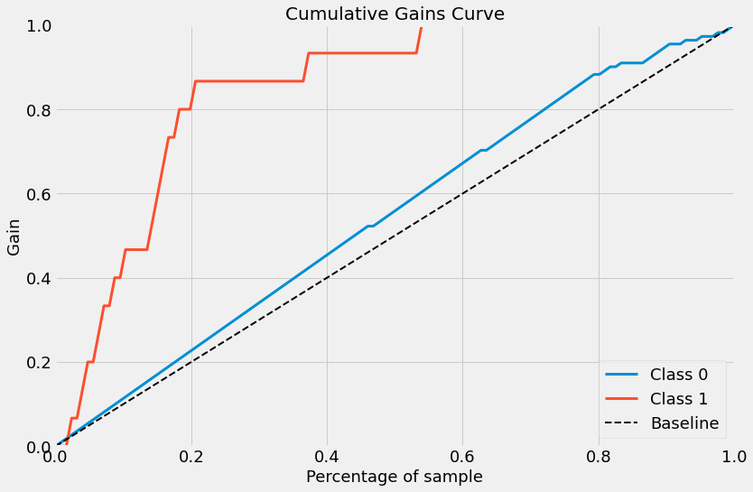

```python
from sklearn import linear_model
import matplotlib.pyplot as plt
import scikitplot as skplt
import pandas as pd

# get what the predicted probabilities are to use creating cumulative gains chart
predictions = lg2.predict_proba(X_test)

skplt.metrics.plot_cumulative_gain(
    y_test, predictions, figsize=(12, 8), title_fontsize=20, text_fontsize=18
)
plt.show()
```

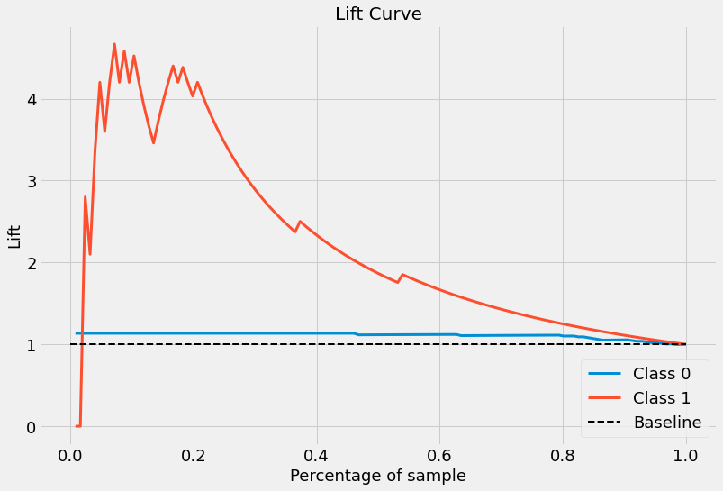

```python
skplt.metrics.plot_lift_curve(
    y_test, predictions, figsize=(12, 8), title_fontsize=20, text_fontsize=18
)
plt.show()
```

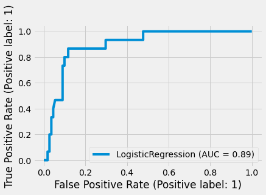

```python
import matplotlib.pyplot as plt
from sklearn import datasets, metrics, model_selection
from sklearn.metrics import plot_roc_curve

plot_roc_curve(lg2,X_test,y_test)
plt.show()
```

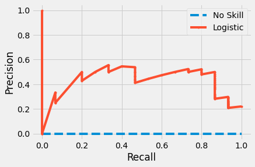

```python
from sklearn.metrics import precision_recall_curve
from matplotlib import pyplot


#Making y_test a Boolean vector
b= '1' <= y_test

# calculate the no skill line as the proportion of the positive class
no_skill = len(y[y==1]) / len(y)
# plot the no skill precision-recall curve
pyplot.plot([0, 1], [no_skill, no_skill], linestyle='--', label='No Skill')
# calculate model precision-recall curve
precision, recall, _ = precision_recall_curve(b.values, predictions[:, 1]
)
# plot the model precision-recall curve
pyplot.plot(recall, precision, marker='.', label='Logistic')
# axis labels
pyplot.xlabel('Recall')
pyplot.ylabel('Precision')
# show the legend
pyplot.legend()
# show the plot
pyplot.show()
```

```python
from sklearn.metrics import auc
auc_score = auc(recall, precision)
auc_score
```

```
0.42434753707171824
```

## Performance on Validation Set

```python
yhat = lg2.predict_proba(X_val)
# keep probabilities for the positive outcome only
probs = yhat[:, 1]
new_pred = to_labels(probs, 0.66)
```

```python
a = y_val.values
a = a.astype('int')
```

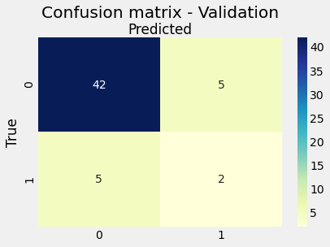

```python
from sklearn.metrics import accuracy_score
import sklearn.metrics as metrics

cnf_matrix = metrics.confusion_matrix(a, new_pred)

labels = [0, 1]
fig, ax = plt.subplots()
tick_marks = np.arange(len(labels))
plt.xticks(tick_marks, labels)
plt.yticks(tick_marks, labels)
# create heatmap
sns.heatmap(pd.DataFrame(cnf_matrix), annot=True, cmap="YlGnBu", fmt='g')
ax.xaxis.set_label_position("top")
plt.title('Confusion matrix - Validation', y=1.1)
plt.ylabel('True')
plt.xlabel('Predicted')
```

```python
print('Accuracy score on Validation Set:', accuracy_score(a, new_pred))
```

```
Accuracy score on Validation Set: 0.8148148148148148
```

```python
f1_score(a, new_pred)
```

```
0.2857142857142857
```

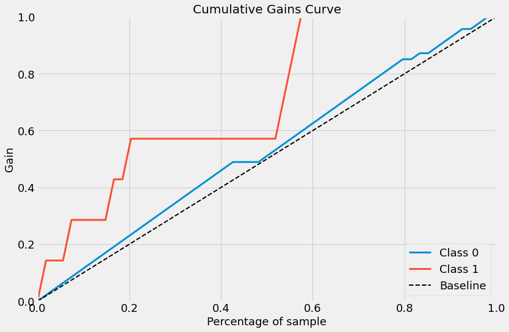

```python
from sklearn import linear_model
import matplotlib.pyplot as plt
import scikitplot as skplt
import pandas as pd

# get what the predicted probabilities are to use creating cumulative gains chart
predictions = lg2.predict_proba(X_val)

skplt.metrics.plot_cumulative_gain(
    y_val, predictions, figsize=(12, 8), title_fontsize=20, text_fontsize=18
)
plt.show()
```

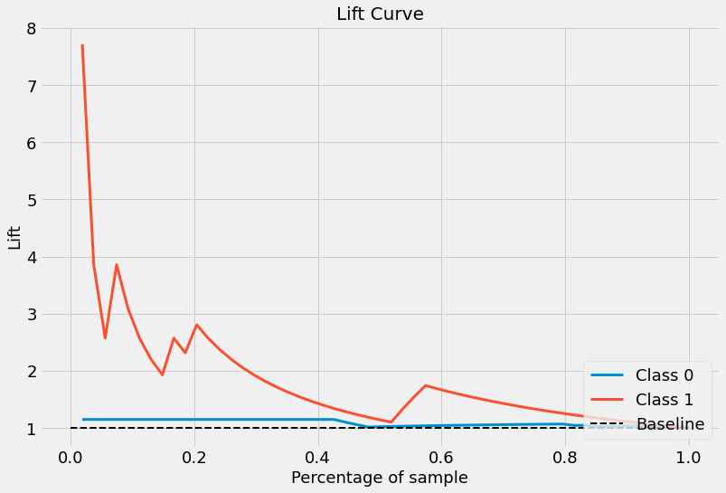

```python
skplt.metrics.plot_lift_curve(
    y_val, predictions, figsize=(12, 8), title_fontsize=20, text_fontsize=18
)
plt.show()
```

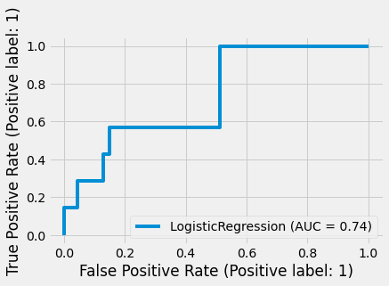

```python
import matplotlib.pyplot as plt
from sklearn import datasets, metrics, model_selection
from sklearn.metrics import plot_roc_curve

plot_roc_curve(lg2,X_val,y_val)
plt.show()
```

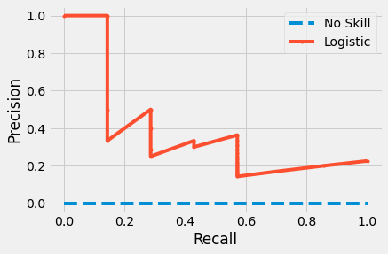

```python
from sklearn.metrics import precision_recall_curve
from matplotlib import pyplot


#Making y_test a Boolean vector
b= '1' <= y_val

# calculate the no skill line as the proportion of the positive class
no_skill = len(y[y==1]) / len(y)
# plot the no skill precision-recall curve
pyplot.plot([0, 1], [no_skill, no_skill], linestyle='--', label='No Skill')
# calculate model precision-recall curve
precision, recall, _ = precision_recall_curve(b.values, predictions[:, 1]
)
# plot the model precision-recall curve
pyplot.plot(recall, precision, marker='.', label='Logistic')
# axis labels
pyplot.xlabel('Recall')
pyplot.ylabel('Precision')
# show the legend
pyplot.legend()
# show the plot
pyplot.show()
```

```python
from sklearn.metrics import auc
auc_score = auc(recall, precision)
auc_score
```

```
0.3709853007842837
```

# Tree Classifier

Let's build a tree classifier

```python
from sklearn.datasets import load_iris
from sklearn.tree import DecisionTreeClassifier
from sklearn.model_selection import train_test_split
from sklearn.metrics import confusion_matrix
from sklearn.tree import export_graphviz
from IPython.display import Image
import pandas as pd
import numpy as np
```

We are going to choose the parameters that maximize the "recall" instead of the accuracy

```python
import sys
if not sys.warnoptions:
    import warnings
    warnings.simplefilter("ignore")

from sklearn.tree import DecisionTreeClassifier
from sklearn.model_selection import GridSearchCV



param_grid = {
    'max_depth': [5, 10, 15, 20, 25],
    'min_impurity_decrease': [0, 0.001, 0.005, 0.01],
    'min_samples_split': [10, 20, 30, 40, 50],
}
grid_search_cv = GridSearchCV(DecisionTreeClassifier(random_state=42), param_grid, verbose=1, cv=5, scoring='recall')
grid_search_cv.fit(X_train, y_train)

grid_search_cv.best_estimator_
```

```
Fitting 5 folds for each of 100 candidates, totalling 500 fits
```

```
DecisionTreeClassifier(max_depth=5, min_impurity_decrease=0,
                       min_samples_split=10, random_state=42)
```

```python
dt = DecisionTreeClassifier(max_depth=5, min_impurity_decrease=0,
                       min_samples_split=10, random_state=42 )
dt.fit(X_train, y_train)
```

```
DecisionTreeClassifier(max_depth=5, min_impurity_decrease=0,
                       min_samples_split=10, random_state=42)
```

## Performance on Test Set

```python
y_pred = dt.predict(X_test)
```

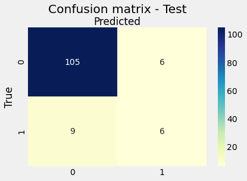

```python
from sklearn.metrics import accuracy_score
import sklearn.metrics as metrics

cnf_matrix = metrics.confusion_matrix(y_test, y_pred)

labels = [0, 1]
fig, ax = plt.subplots()
tick_marks = np.arange(len(labels))
plt.xticks(tick_marks, labels)
plt.yticks(tick_marks, labels)
# create heatmap
sns.heatmap(pd.DataFrame(cnf_matrix), annot=True, cmap="YlGnBu", fmt='g')
ax.xaxis.set_label_position("top")
plt.title('Confusion matrix - Test', y=1.1)
plt.ylabel('True')
plt.xlabel('Predicted')
```

```python
print('Accuracy on Test :', accuracy_score(y_test, y_pred))
```

```
Accuracy on Test : 0.8809523809523809
```

```python
pred_tree = y_pred.astype('int')
a = y_test.values
a = a.astype('int')
f1_score(a, pred_tree)
```

```
0.4444444444444445
```

```python
y_prob = dt.predict_proba(X_test)
```

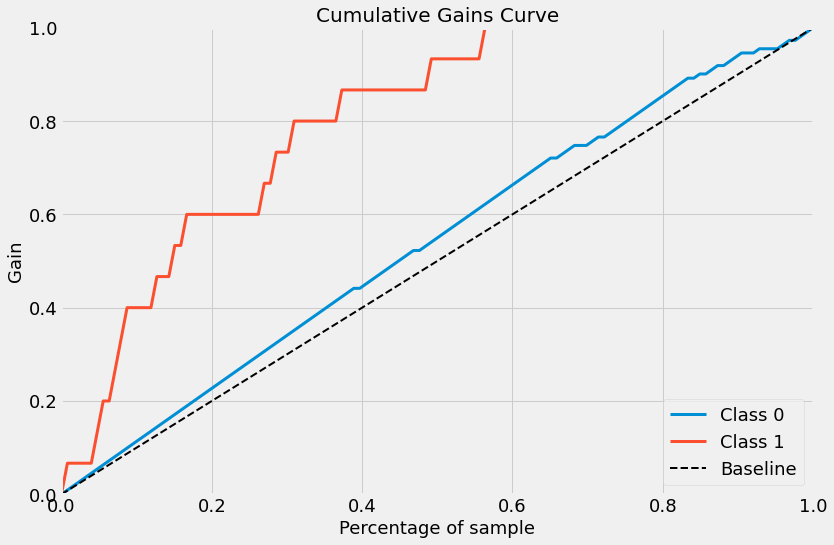

```python
skplt.metrics.plot_cumulative_gain(
    y_test, y_prob, figsize=(12, 8), title_fontsize=20, text_fontsize=18
)
plt.show()
```

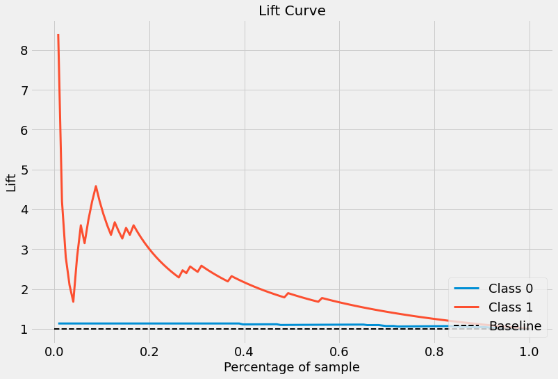

```python
skplt.metrics.plot_lift_curve(
    y_test, y_prob, figsize=(12, 8), title_fontsize=20, text_fontsize=18
)
plt.show()
```

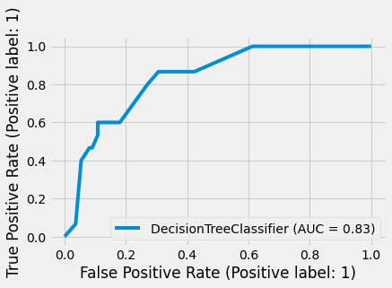

```python
plot_roc_curve(dt,X_test,y_test)
plt.show()
```

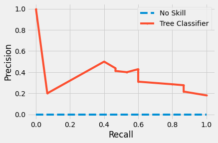

```python
from sklearn.metrics import precision_recall_curve
from matplotlib import pyplot


#Making y_test a Boolean vector
y_test= '1' <= y_test

# calculate the no skill line as the proportion of the positive class
no_skill = len(y[y==1]) / len(y)
# plot the no skill precision-recall curve
pyplot.plot([0, 1], [no_skill, no_skill], linestyle='--', label='No Skill')
# calculate model precision-recall curve
precision, recall, _ = precision_recall_curve(y_test.values, y_prob[:, 1]
)
# plot the model precision-recall curve
pyplot.plot(recall, precision, marker='.', label='Tree Classifier')
# axis labels
pyplot.xlabel('Recall')
pyplot.ylabel('Precision')
# show the legend
pyplot.legend()
# show the plot
pyplot.show()
```

```python
from sklearn.metrics import auc
auc_score = auc(recall, precision)
auc_score
```

```
0.347436754040542
```

## Performance on Validation set

```python
y_pred = dt.predict(X_val)
```

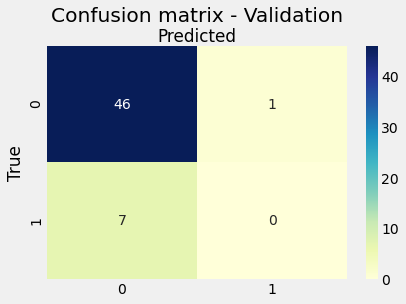

```python
from sklearn.metrics import accuracy_score
import sklearn.metrics as metrics

cnf_matrix = metrics.confusion_matrix(y_val, y_pred)

labels = [0, 1]
fig, ax = plt.subplots()
tick_marks = np.arange(len(labels))
plt.xticks(tick_marks, labels)
plt.yticks(tick_marks, labels)
# create heatmap
sns.heatmap(pd.DataFrame(cnf_matrix), annot=True, cmap="YlGnBu", fmt='g')
ax.xaxis.set_label_position("top")
plt.title('Confusion matrix - Validation', y=1.1)
plt.ylabel('True')
plt.xlabel('Predicted')
```

```python
print('Accuracy on Test :', accuracy_score(y_val, y_pred))
```

```
Accuracy on Test : 0.8518518518518519
```

```python
pred_tree = y_pred.astype('int')
b = y_val.values
b = b.astype('int')
f1_score(b, pred_tree)
```

```
0.0
```

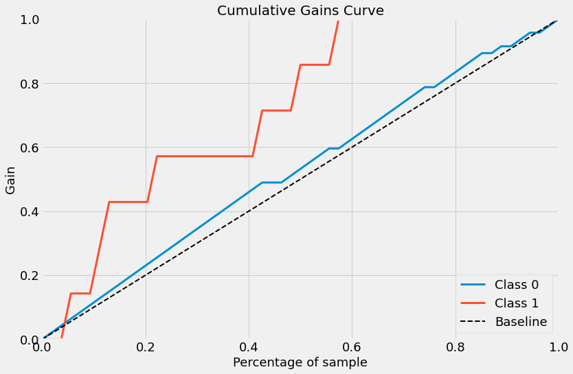

```python
from sklearn import linear_model
import matplotlib.pyplot as plt
import scikitplot as skplt
import pandas as pd

# get what the predicted probabilities are to use creating cumulative gains chart
predictions = dt.predict_proba(X_val)

skplt.metrics.plot_cumulative_gain(
    y_val, predictions, figsize=(12, 8), title_fontsize=20, text_fontsize=18
)
plt.show()
```

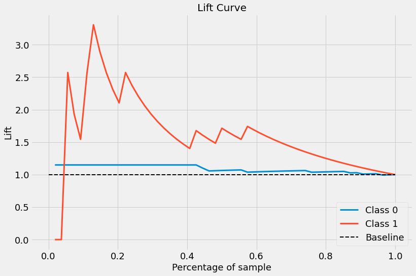

```python
skplt.metrics.plot_lift_curve(
    y_val, predictions, figsize=(12, 8), title_fontsize=20, text_fontsize=18
)
plt.show()
```

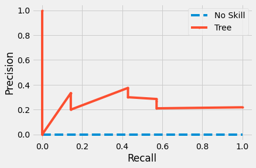

```python
from sklearn.metrics import precision_recall_curve
from matplotlib import pyplot


#Making y_test a Boolean vector
y_val= '1' <= y_val

# calculate the no skill line as the proportion of the positive class
no_skill = len(y[y==1]) / len(y)
# plot the no skill precision-recall curve
pyplot.plot([0, 1], [no_skill, no_skill], linestyle='--', label='No Skill')
# calculate model precision-recall curve
precision, recall, _ = precision_recall_curve(y_val.values, predictions[:, 1]
)
# plot the model precision-recall curve
pyplot.plot(recall, precision, marker='.', label='Tree')
# axis labels
pyplot.xlabel('Recall')
pyplot.ylabel('Precision')
# show the legend
pyplot.legend()
# show the plot
pyplot.show()
```

```python
auc_score = auc(recall, precision)
auc_score
```

```
0.2397768976011457
```